# Answers to Exercises: Let’s practice more LMs

Alexandre Courtiol

2018-05-15

## Disclamer

In this vignette I illustrate the key steps required to solve the exercises. By no means I am trying to provide a detailed report of the analysis of each dataset. Any such report would need additional analyses and results would have to be written in good English, not in telegraphic style or lines of codes. I have also written this vignette very quickly, so double check I did not mess anything up…

# Dataset: chickwts (difficulty = 0/5)

## Goal

- compare the effectiveness of various feed supplements on the weights of six weeks old chickens
- predict the proportion of chicken over 300 grams for each feed supplements

## Exploring the data

We always start by looking at the data we have:

```r
str(chickwts)
```

```
## 'data.frame':    71 obs. of  2 variables:
##  $ weight: num  179 160 136 227 217 168 108 124 143 140 ...
##  $ feed  : Factor w/ 6 levels "casein","horsebean",..: 2 2 2 2 2 2 2 2 2 2 ...
```

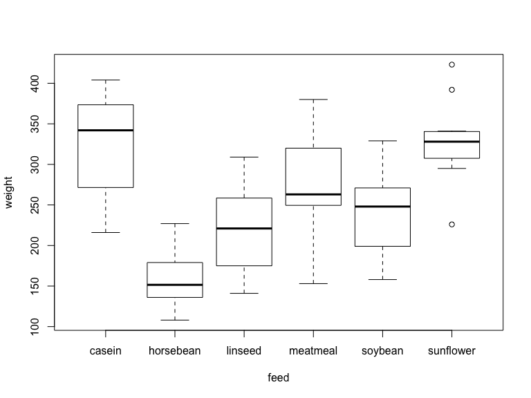

```r
plot(weight ~ feed, data = chickwts)
```

I don’t know much about chicken but the values seem alright.

We can also check the structure of the experimental design using the cross product of the design matrix we are planing to use for the fitting procedure:

```r
crossprod(model.matrix( ~ feed - 1, data = chickwts))
```

```
##               feedcasein feedhorsebean feedlinseed feedmeatmeal
## feedcasein            12             0           0            0
## feedhorsebean          0            10           0            0
## feedlinseed            0             0          12            0
## feedmeatmeal           0             0           0           11
## feedsoybean            0             0           0            0
## feedsunflower          0             0           0            0
##               feedsoybean feedsunflower
## feedcasein              0             0
## feedhorsebean           0             0
## feedlinseed             0             0
## feedmeatmeal            0             0
## feedsoybean            14             0
## feedsunflower           0            12
```

Removing the intercept when there is only one qualitative predictor gives the counts directly.

Here, because there is only one factor involved, we could also have directly used the following:

```r
table(chickwts$feed)
```

```
##
##    casein horsebean   linseed  meatmeal   soybean sunflower
##        12        10        12        11        14        12
```

We check if there is any missing data:

```r
any(is.na(chickwts))
```

```
## [1] FALSE
```

Great! There is no missing data.

## Fitting the model

We fit the model:

```r
(mod_chick <- lm(weight ~ feed, data = chickwts))
```

```
##
## Call:
## lm(formula = weight ~ feed, data = chickwts)
##
## Coefficients:
##   (Intercept)  feedhorsebean    feedlinseed   feedmeatmeal    feedsoybean
##       323.583       -163.383       -104.833        -46.674        -77.155
## feedsunflower
##         5.333
```

## Checking the assumptions

- linearity cannot be an issue here as we only have one qualitative predictor.
- multicollinearity is not an issue either has each chick has received a different feeding treatment (see cross-product above).
- fixed values for the predictor: unless the diet has not been recorded correctly, there should not been any problem.

Let’s have a look at the residuals of the model:

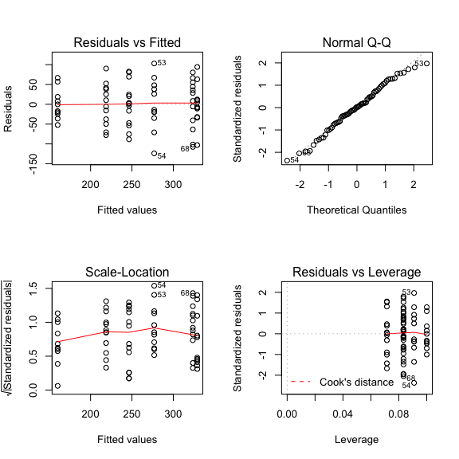

```r
par(mfrow = c(2, 2))
plot(mod_chick)
```

Everything looks very good. The errors should thus be independent, homoscedastic and normally distributed.

## Testing the effect of diet

```r
anova(mod_chick)
```

```
## Analysis of Variance Table
##
## Response: weight
##           Df Sum Sq Mean Sq F value    Pr(>F)
## feed       5 231129   46226  15.365 5.936e-10 ***
## Residuals 65 195556    3009
## ---
## Signif. codes:  0 '***' 0.001 '**' 0.01 '*' 0.05 '.' 0.1 ' ' 1
```

The diet seems to influence significantly the growth of chicken (F = `15.36`, df1 = `5`, df2 = `65`, p-value < 0.001).

## Predicting the mean effect of each diet

```r
pred <- predict(mod_chick, newdata = data.frame(feed = levels(chickwts$feed)),
        interval = "confidence")
rownames(pred) <- levels(chickwts$feed)
pred
```

```
##                fit      lwr      upr
## casein    323.5833 291.9608 355.2058
## horsebean 160.2000 125.5593 194.8407
## linseed   218.7500 187.1275 250.3725
## meatmeal  276.9091 243.8805 309.9377
## soybean   246.4286 217.1518 275.7053
## sunflower 328.9167 297.2942 360.5392
```

Let’s plot this:

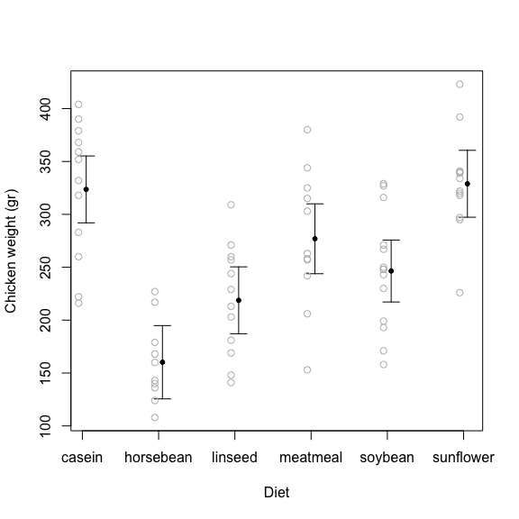

```r
plot(pred[, "fit"] ~ I(1:nrow(pred) + 0.05), axes = FALSE, pch = 20,
     ylim = range(mod_chick$model$weight),
     ylab = "Chicken weight (gr)", xlab = "Diet")
axis(1, 1:nrow(pred), labels = rownames(pred))
axis(2)
box()
for (row in 1:nrow(pred)) {
  arrows(x0 = row + 0.05, y0 = pred[row, "lwr"], x1 = row + 0.05, y1 = pred[row, "upr"],
         code = 3, angle = 90, length = 0.1)
  diet <- levels(chickwts$feed)[row]
  weights.to.plot <- chickwts$weight[chickwts$feed == diet]
  points(rep(row, length(weights.to.plot)) - 0.05, weights.to.plot, col = "grey")
  }
```

The plot shows the predicted mean weight of chicken for each diet (black) with associated 95% confidence intervals. The observed weights of the chicken included in the analysis are represented by grey dots.

To make the plot even better we could have sorted the diet by increasing order of their effects.

## Testing which diet differs from each others

```r
summary(posthoc <- multcomp::glht(mod_chick, linfct = multcomp::mcp(feed = "Tukey")))
```

```
##
##   Simultaneous Tests for General Linear Hypotheses
##
## Multiple Comparisons of Means: Tukey Contrasts
##
##
## Fit: lm(formula = weight ~ feed, data = chickwts)
##
## Linear Hypotheses:
##                            Estimate Std. Error t value Pr(>|t|)
## horsebean - casein == 0    -163.383     23.485  -6.957  < 0.001 ***
## linseed - casein == 0      -104.833     22.393  -4.682  < 0.001 ***
## meatmeal - casein == 0      -46.674     22.896  -2.039  0.33203
## soybean - casein == 0       -77.155     21.578  -3.576  0.00844 **
## sunflower - casein == 0       5.333     22.393   0.238  0.99989
## linseed - horsebean == 0     58.550     23.485   2.493  0.14126
## meatmeal - horsebean == 0   116.709     23.966   4.870  < 0.001 ***
## soybean - horsebean == 0     86.229     22.710   3.797  0.00415 **
## sunflower - horsebean == 0  168.717     23.485   7.184  < 0.001 ***
## meatmeal - linseed == 0      58.159     22.896   2.540  0.12719
## soybean - linseed == 0       27.679     21.578   1.283  0.79298
## sunflower - linseed == 0    110.167     22.393   4.920  < 0.001 ***
## soybean - meatmeal == 0     -30.481     22.100  -1.379  0.73876
## sunflower - meatmeal == 0    52.008     22.896   2.271  0.22036
## sunflower - soybean == 0     82.488     21.578   3.823  0.00385 **
## ---
## Signif. codes:  0 '***' 0.001 '**' 0.01 '*' 0.05 '.' 0.1 ' ' 1
## (Adjusted p values reported -- single-step method)
```

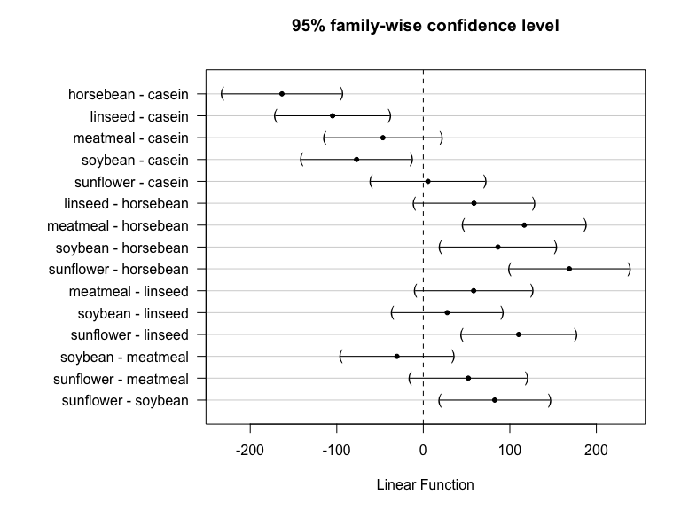

```r
par(oma = c(0, 8, 0, 0))
plot(posthoc)
```

## Predicting the proportion of chicken heavier than 300 grams

```r
pred2 <- predict(mod_chick,
                newdata = data.frame(feed = levels(chickwts$feed)),
                interval = "prediction",
                se.fit = TRUE)

se.pred <- sqrt(pred2$se.fit^2 + pred2$residual.scale^2)

freq_more300 <- pnorm(q = 300,
                      mean = pred2$fit[, "fit"],
                      sd = se.pred, lower.tail = FALSE)

output <- cbind(pred2$fit, "%>300gr" = round(freq_more300, 2))

rownames(output) <- levels(chickwts$feed)

output
```

```
##                fit       lwr      upr %>300gr
## casein    323.5833 209.56675 437.5999    0.66
## horsebean 160.2000  45.30971 275.0903    0.01
## linseed   218.7500 104.73342 332.7666    0.08
## meatmeal  276.9091 162.49454 391.3236    0.34
## soybean   246.4286 133.04018 359.8170    0.17
## sunflower 328.9167 214.90008 442.9333    0.69
```

We can plot this:

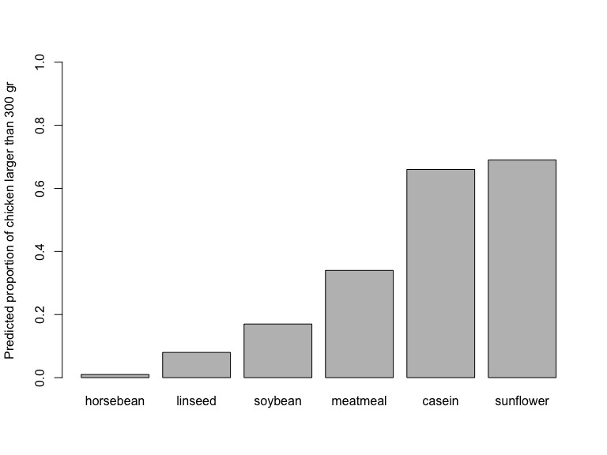

```r
barplot(sort(output[, "%>300gr"]), ylim = c(0, 1), ylab = "Predicted proportion of chicken larger than 300 gr")
```

We clean the session for the next exercise:

```r
rm(list = ls())
```

# Dataset: InsectSprays (difficulty = 2/5)

## Goal

- compare the effectiveness of various insecticides on the number of insects in agricultural experimental units
- what is the efficiency of spray C?

## Exploring the data

```r
str(InsectSprays)
```

```
## 'data.frame':    72 obs. of  2 variables:
##  $ count: num  10 7 20 14 14 12 10 23 17 20 ...
##  $ spray: Factor w/ 6 levels "A","B","C","D",..: 1 1 1 1 1 1 1 1 1 1 ...
```

```r
range(InsectSprays$count)
```

```
## [1]  0 26
```

```r
table(InsectSprays$spray)
```

```
##
##  A  B  C  D  E  F
## 12 12 12 12 12 12
```

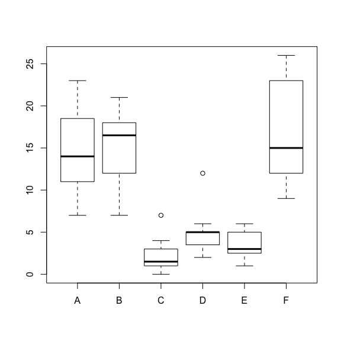

```r
boxplot(count ~ spray, data = InsectSprays)
```

```r
any(is.na(InsectSprays))
```

```
## [1] FALSE
```

## Fitting the model

```r
(mod_insect <- lm(count ~ spray, data = InsectSprays))
```

```
##
## Call:
## lm(formula = count ~ spray, data = InsectSprays)
##
## Coefficients:
## (Intercept)       sprayB       sprayC       sprayD       sprayE
##     14.5000       0.8333     -12.4167      -9.5833     -11.0000
##      sprayF
##      2.1667
```

## Checking the assumptions

As for the dataset `chickwts`, because we only study the effect of one qualitative predictor, we expect linearity and multicollinearity, and that the values for the predictor are fixed as assumed. We can thus directly turn to the analysis of the prediction error.

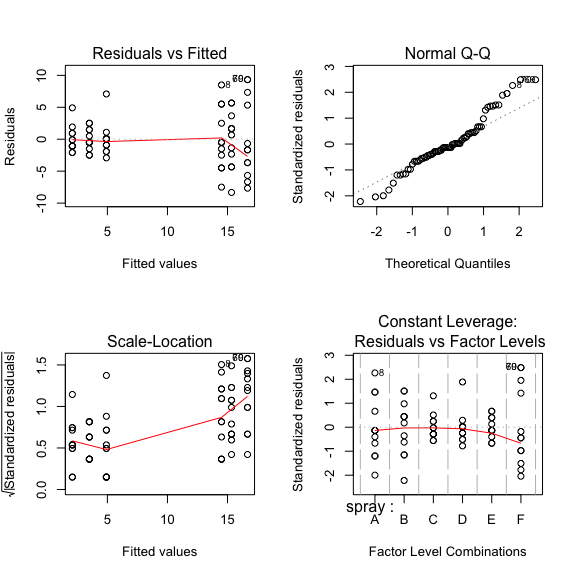

```r
par(mfrow = c(2, 2))
plot(mod_insect)
```

That does not look so good. There seem to be some heteroscedasticity in the data. Let’s test this possibility:

```r
lmtest::bptest(mod_insect)
```

```
##
##  studentized Breusch-Pagan test
##
## data:  mod_insect
## BP = 20.701, df = 5, p-value = 0.0009223
```

The Breusch-Pagan test shows that we can reject the assumption of homoscedasticity. One option would be to try to use GLM but we have not yet seen this, so let’s try to reduce the problems and apply a LM fit anyhow. The first thing top try to solve the problems is to use a power transformation of the response variable.

## Box Cox

For the Box Cox transformation to work, we need all the values to be strictly positive, but we saw that the minimum value is zero, so let’s start by adding one to every count and let’s refit the model.

```r
InsectSprays$count_bis <- InsectSprays$count + 1
mod_insect_bis <- update(mod_insect, count_bis ~ .)
```

We can now start the Box Cox analysis:

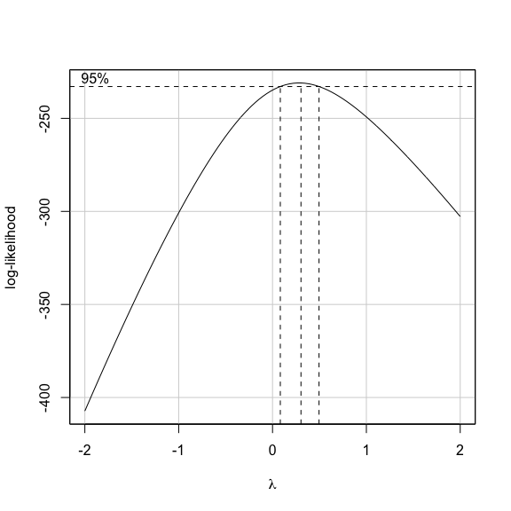

```r
car::boxCox(mod_insect_bis)
```

```r
summary(bc <- car::powerTransform(mod_insect_bis))
```

```
## bcPower Transformation to Normality
##    Est Power Rounded Pwr Wald Lwr Bnd Wald Upr Bnd
## Y1     0.284        0.33       0.0791       0.4889
##
## Likelihood ratio test that transformation parameter is equal to 0
##  (log transformation)
##                            LRT df     pval
## LR test, lambda = (0) 7.711169  1 0.005488
##
## Likelihood ratio test that no transformation is needed
##                            LRT df       pval
## LR test, lambda = (1) 36.50347  1 1.5239e-09
```

The estimated value for lambda is close to 1/3 which corresponds to a cube root exponent to the observation but this is not particularly meaningful so we will stick to the best estimate for lambda which is `0.2840108` and stored in the object bc$lambda.

Let’s fit the model on the transformed data and display the new diagnostic plots:

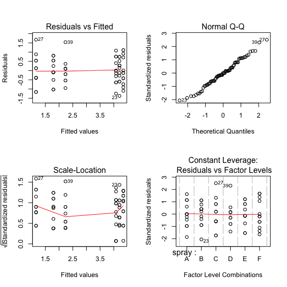

```r
InsectSprays$count_bc <- car::bcPower(InsectSprays$count_bis, bc$lambda)
mod_insect_bc <- update(mod_insect_bis, count_bc ~ .)
par(mfrow = c(2, 2))
plot(mod_insect_bc)
```

That looks fantastic! The heteroscedasticity is gone:

```r
lmtest::bptest(mod_insect_bc)
```

```
##
##  studentized Breusch-Pagan test
##
## data:  mod_insect_bc
## BP = 2.6316, df = 5, p-value = 0.7566
```

The lack of dependence should not be an issue (although the original paper where these data have been published showed that the experimental design was not as simple as the dataset here suggests), but let’s check anyhow:

```r
lmtest::dwtest(mod_insect_bc)
```

```
##
##  Durbin-Watson test
##
## data:  mod_insect_bc
## DW = 1.921, p-value = 0.1735
## alternative hypothesis: true autocorrelation is greater than 0
```

```r
car::durbinWatsonTest(mod_insect_bc)
```

```
##  lag Autocorrelation D-W Statistic p-value
##    1      0.03029067      1.920983   0.334
##  Alternative hypothesis: rho != 0
```

Although surprising differences between the two implementation of this test, independence is not rejected.

The normality looked good on the plots but we could also test it:

```r
nortest::lillie.test(mod_insect_bc$residuals)
```

```
##
##  Lilliefors (Kolmogorov-Smirnov) normality test
##
## data:  mod_insect_bc$residuals
## D = 0.067137, p-value = 0.5842
```

```r
shapiro.test(mod_insect_bc$residuals)
```

```
##
##  Shapiro-Wilk normality test
##
## data:  mod_insect_bc$residuals
## W = 0.98766, p-value = 0.7087
```

Again, no issue here.

## Testing the effect of insecticides

```r
anova(mod_insect_bc)
```

```
## Analysis of Variance Table
##
## Response: count_bc
##           Df  Sum Sq Mean Sq F value    Pr(>F)
## spray      5 118.339 23.6677  48.818 < 2.2e-16 ***
## Residuals 66  31.998  0.4848
## ---
## Signif. codes:  0 '***' 0.001 '**' 0.01 '*' 0.05 '.' 0.1 ' ' 1
```

The type of insecticide seems to influence significantly the number of insects counted (F = `48.82`, df1 = `5`, df2 = `66`, p-value < 0.001).

## Predicting the effect of spray C

```r
(meanC_BC <- predict(mod_insect_bc, newdata = data.frame(spray = "C"), interval = "confidence"))
```

```
##        fit      lwr      upr
## 1 1.159628 0.758315 1.560941
```

This corresponds to the number of insects + 1 on the Box Cox scale. Thus we need to transform this result back on the original scale:

```r
(meanC <- ((meanC_BC * bc$lambda) + 1)^(1/bc$lambda) - 1)
```

```
##        fit       lwr      upr
## 1 1.724768 0.9872734 2.640147
```

We thus expect to find on average (95%CI) `1.72` (`0.99` – `2.64`) insects on agricultural experimental units treated with the insecticide C.

We clean the session for the next exercise:

```r
rm(list = ls())
```

# Dataset: swiss (difficulty = 1/5)

## Goal

- plot the influence of potential determinant of fertility variation between Swiss provinces

## Exploring the data

```r
str(swiss)
```

```
## 'data.frame':    47 obs. of  6 variables:
##  $ Fertility       : num  80.2 83.1 92.5 85.8 76.9 76.1 83.8 92.4 82.4 82.9 ...
##  $ Agriculture     : num  17 45.1 39.7 36.5 43.5 35.3 70.2 67.8 53.3 45.2 ...
##  $ Examination     : int  15 6 5 12 17 9 16 14 12 16 ...
##  $ Education       : int  12 9 5 7 15 7 7 8 7 13 ...
##  $ Catholic        : num  9.96 84.84 93.4 33.77 5.16 ...
##  $ Infant.Mortality: num  22.2 22.2 20.2 20.3 20.6 26.6 23.6 24.9 21 24.4 ...
```

```r
summary(swiss)
```

```
##    Fertility      Agriculture     Examination      Education
##  Min.   :35.00   Min.   : 1.20   Min.   : 3.00   Min.   : 1.00
##  1st Qu.:64.70   1st Qu.:35.90   1st Qu.:12.00   1st Qu.: 6.00
##  Median :70.40   Median :54.10   Median :16.00   Median : 8.00
##  Mean   :70.14   Mean   :50.66   Mean   :16.49   Mean   :10.98
##  3rd Qu.:78.45   3rd Qu.:67.65   3rd Qu.:22.00   3rd Qu.:12.00
##  Max.   :92.50   Max.   :89.70   Max.   :37.00   Max.   :53.00
##     Catholic       Infant.Mortality
##  Min.   :  2.150   Min.   :10.80
##  1st Qu.:  5.195   1st Qu.:18.15
##  Median : 15.140   Median :20.00
##  Mean   : 41.144   Mean   :19.94
##  3rd Qu.: 93.125   3rd Qu.:21.70
##  Max.   :100.000   Max.   :26.60
```

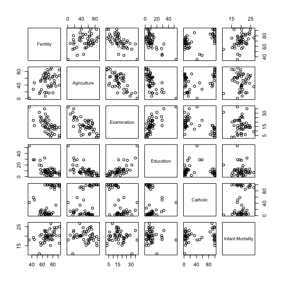

```r
pairs(swiss)
```

```r
any(is.na(swiss))
```

```
## [1] FALSE
```

## Fitting the model

```r
mod_swiss <- lm(Fertility ~ ., data = swiss)
```

## Checking the assumptions

### Linearity

Let’s examine the linearity assumption by plotting the residuals against each column of the design matrix (but the intercept):

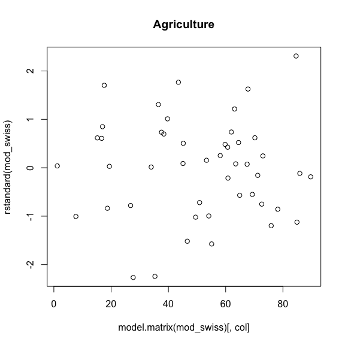

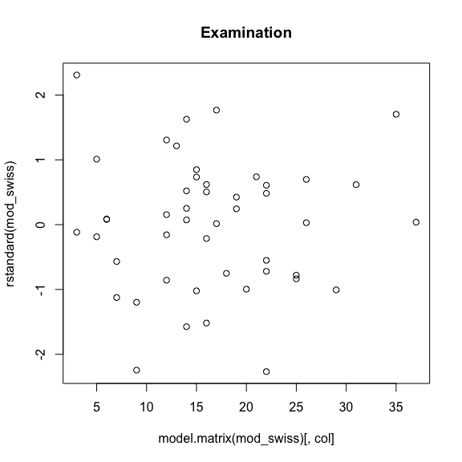

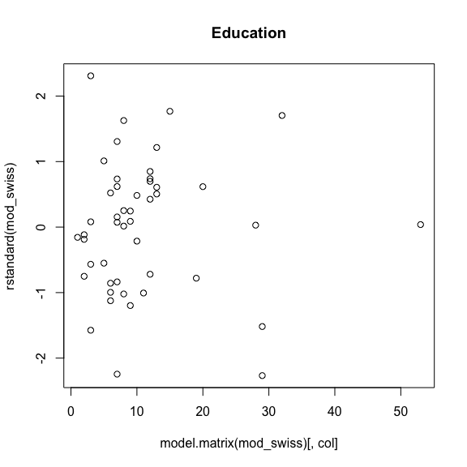

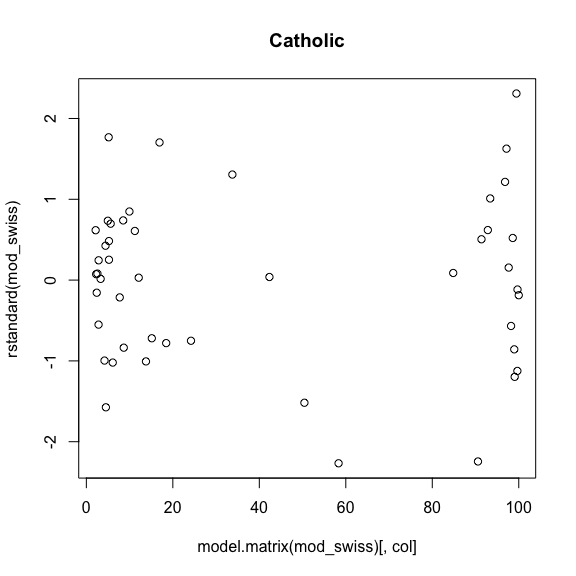

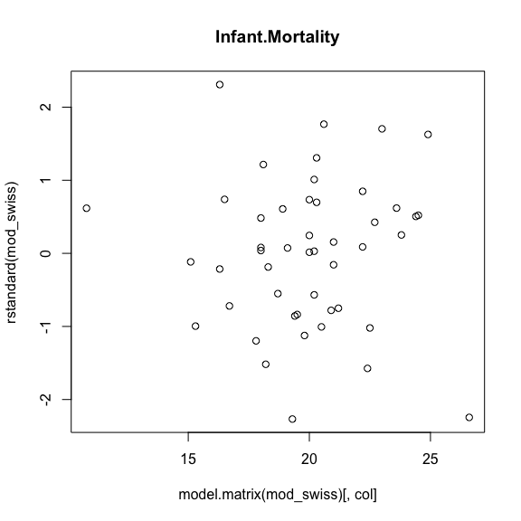

```r
for (col in 2:ncol(model.matrix(mod_swiss))) {
  plot(rstandard(mod_swiss) ~ model.matrix(mod_swiss)[, col])
  title(main = colnames(model.matrix(mod_swiss))[col])
}
```

No obvious non-linear pattern emerges.

### Multicollinearity

We can look at the correlation between the column vectors of the model matrix:

```r
cor(model.matrix(mod_swiss)[, -1])  ## we discard the intercept for that
```

```
##                  Agriculture Examination   Education   Catholic
## Agriculture       1.00000000  -0.6865422 -0.63952252  0.4010951
## Examination      -0.68654221   1.0000000  0.69841530 -0.5727418
## Education        -0.63952252   0.6984153  1.00000000 -0.1538589
## Catholic          0.40109505  -0.5727418 -0.15385892  1.0000000
## Infant.Mortality -0.06085861  -0.1140216 -0.09932185  0.1754959
##                  Infant.Mortality
## Agriculture           -0.06085861
## Examination           -0.11402160
## Education             -0.09932185
## Catholic               0.17549591
## Infant.Mortality       1.00000000
```

We can also look at the correlation between parameter estimates:

```r
cov2cor(vcov(mod_swiss))
```

```
##                  (Intercept) Agriculture  Examination  Education
## (Intercept)       1.00000000  -0.6442976 -0.442443115 -0.1435385
## Agriculture      -0.64429763   1.0000000  0.244885485  0.3722156
## Examination      -0.44244312   0.2448855  1.000000000 -0.5877430
## Education        -0.14353852   0.3722156 -0.587742991  1.0000000
## Catholic         -0.05876889  -0.2062657  0.573548644 -0.4649428
## Infant.Mortality -0.79913888   0.2446549  0.003593513  0.1755760
##                     Catholic Infant.Mortality
## (Intercept)      -0.05876889     -0.799138883
## Agriculture      -0.20626575      0.244654895
## Examination       0.57354864      0.003593513
## Education        -0.46494277      0.175576011
## Catholic          1.00000000     -0.204087269
## Infant.Mortality -0.20408727      1.000000000
```

There are some noticeable correlations between predictors and between parameter estimates (the very strong correlation between slopes and the intercept are to be expected, as well as the one between a variable and itself). Let’s double check the extent to which multicollinearity could be an issue by looking at the variance inflation factors:

```r
vif(mod_swiss)
```

```
##      Agriculture      Examination        Education         Catholic
##         2.284129         3.675420         2.774943         1.937160
## Infant.Mortality
##         1.107542
```

The situation is not ideal but nothing looks catastrophic. Let’s see if the situation gets better once the variable `Examination` is omitted:

```r
mod_swiss_bis <- update(mod_swiss, . ~ . - Examination)
vif(mod_swiss_bis)
```

```
##      Agriculture        Education         Catholic Infant.Mortality
##         2.147153         1.816361         1.299916         1.107528
```

The situation is much better so we will preform the prediction of the model with examination and on the model without for the sake of comparison.

### Fixed values for predictor

Because we do not know on how many individuals the percentages have been based, we will assume that they did so on large sample and that this assumption is fulfilled.

### Errors

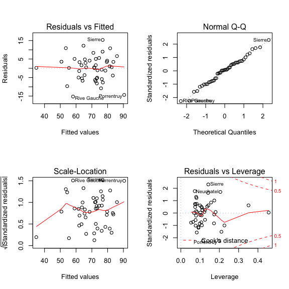

```r
par(mfrow = c(2, 2))
plot(mod_swiss)
```

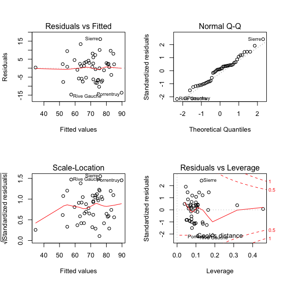

```r
plot(mod_swiss_bis)
```

Both models look alright.

## Comparison to the null model

Because the model involves several predictors, before anything else we need to make sure that the overall model offers a higher goodness of fit than the null model:

```r
mod_swiss_H0 <- update(mod_swiss, . ~ 1)
anova(mod_swiss_H0, mod_swiss)
```

```
## Analysis of Variance Table
##
## Model 1: Fertility ~ 1
## Model 2: Fertility ~ Agriculture + Examination + Education + Catholic +
##     Infant.Mortality
##   Res.Df  RSS Df Sum of Sq      F    Pr(>F)
## 1     46 7178
## 2     41 2105  5    5072.9 19.761 5.594e-10 ***
## ---
## Signif. codes:  0 '***' 0.001 '**' 0.01 '*' 0.05 '.' 0.1 ' ' 1
```

```r
anova(mod_swiss_H0, mod_swiss_bis)
```

```
## Analysis of Variance Table
##
## Model 1: Fertility ~ 1
## Model 2: Fertility ~ Agriculture + Education + Catholic + Infant.Mortality
##   Res.Df    RSS Df Sum of Sq      F    Pr(>F)
## 1     46 7178.0
## 2     42 2158.1  4    5019.9 24.424 1.717e-10 ***
## ---
## Signif. codes:  0 '***' 0.001 '**' 0.01 '*' 0.05 '.' 0.1 ' ' 1
```

Both of our models are fit the data clearly better than the null model.

## Plotting the effect of the potential determinant of fertility

Because this is a simple LM, we can try to use the function `allEffects` from the package `effects` to do that:

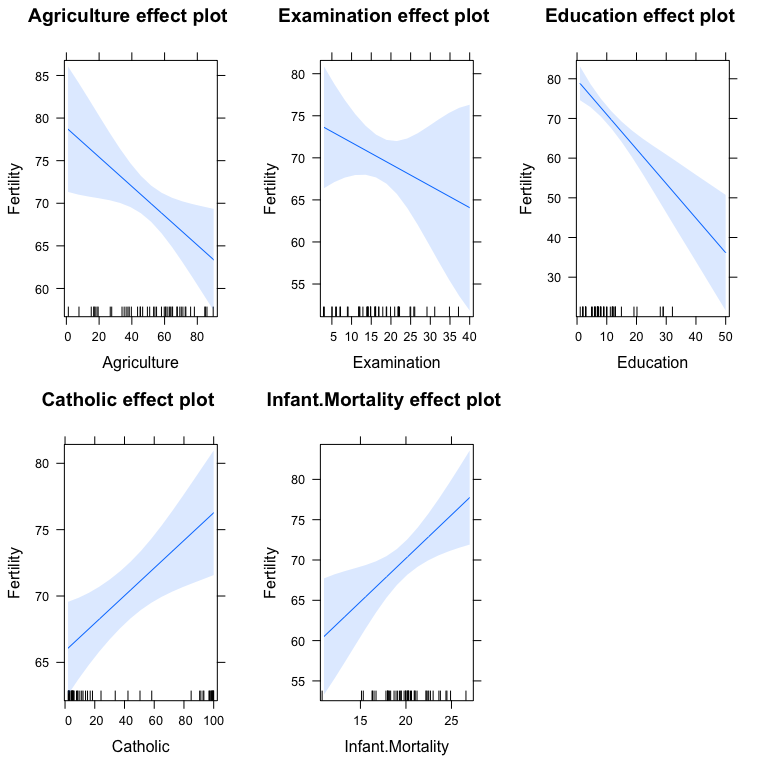

```r
plot(effects::allEffects(mod_swiss))
```

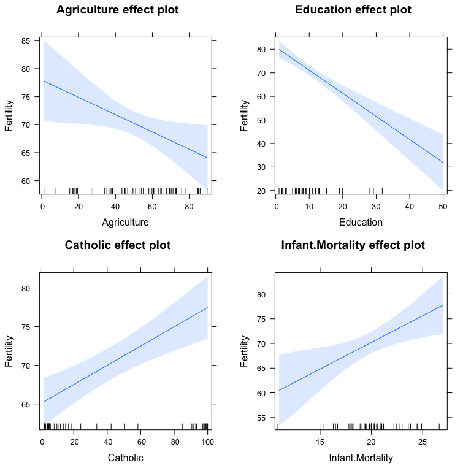

```r
plot(effects::allEffects(mod_swiss_bis))
```

Many other packages can probably do the same. One example is `visreg`:

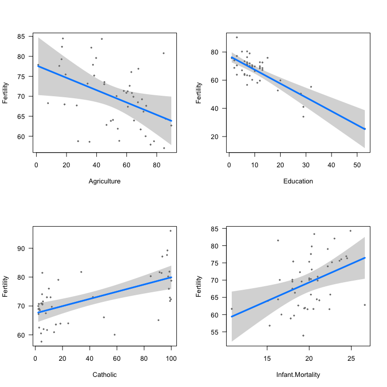

```r
par(mfrow = c(2, 2))
plot(visreg::visreg(mod_swiss_bis))
```

Both models predict the same overall trends. To illustrate the difference in predicted values between the two models, one would have to do the plot manually instead of using some easy package. Let’s do that to illustrate how the prediction for the mean effect of education differ between models:

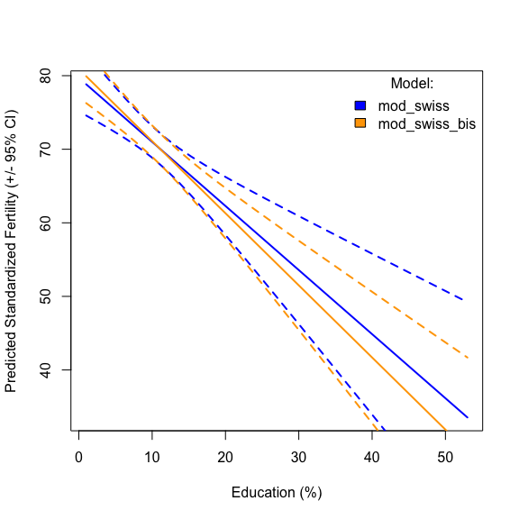

```r
data.for.pred <- expand.grid("Agriculture" = mean(swiss$Agriculture),
                       "Examination" = mean(swiss$Examination),
                       "Education" = seq(min(swiss$Education), max(swiss$Education), length = 30),
                       "Catholic" = mean(swiss$Catholic),
                       "Infant.Mortality" = mean(swiss$Infant.Mortality)
                       )
pred1 <- predict(mod_swiss, newdata = data.for.pred, interval = "confidence")
pred2 <- predict(mod_swiss_bis, newdata = data.for.pred, interval = "confidence")
plot(pred1[, "fit"] ~ data.for.pred$Education, col = "blue", lwd = 2, type = "l",
     ylab = "Predicted Standardized Fertility (+/- 95% CI)", xlab = "Education (%)")
points(pred1[, "lwr"] ~ data.for.pred$Education,
       col = "blue", lwd = 2, lty = 2, type = "l")
points(pred1[, "upr"] ~ data.for.pred$Education,
       col = "blue", lwd = 2, lty = 2, type = "l")
points(pred2[, "fit"] ~ data.for.pred$Education,
       col = "orange", lwd = 2, type = "l")
points(pred2[, "lwr"] ~ data.for.pred$Education,
       col = "orange", lwd = 2, lty = 2, type = "l")
points(pred2[, "upr"] ~ data.for.pred$Education,
       col = "orange", lwd = 2, lty = 2, type = "l")
legend("topright", fill = c("blue", "orange"),
       legend = c("mod_swiss", "mod_swiss_bis"), title = "Model:", bty = "n")
```

Note that while predicting the effect of `Education` we set all other covariates to their mean.

We clean the session for the next exercise:

```r
rm(list = ls())
```

# Dataset: trees (difficulty = 3/5)

## Goal

- compare the approximation of the volume of wood given by $\text{Volume} = c*\text{Height}*\text{Girth}^2$ (with c to be estimated) to the usual consideration that a tree trunk is a cylinder

## Exploring the data

```r
str(trees)
```

```
## 'data.frame':    31 obs. of  3 variables:
##  $ Girth : num  8.3 8.6 8.8 10.5 10.7 10.8 11 11 11.1 11.2 ...
##  $ Height: num  70 65 63 72 81 83 66 75 80 75 ...
##  $ Volume: num  10.3 10.3 10.2 16.4 18.8 19.7 15.6 18.2 22.6 19.9 ...
```

```r
summary(trees)
```

```
##      Girth           Height       Volume
##  Min.   : 8.30   Min.   :63   Min.   :10.20
##  1st Qu.:11.05   1st Qu.:72   1st Qu.:19.40
##  Median :12.90   Median :76   Median :24.20
##  Mean   :13.25   Mean   :76   Mean   :30.17
##  3rd Qu.:15.25   3rd Qu.:80   3rd Qu.:37.30
##  Max.   :20.60   Max.   :87   Max.   :77.00
```

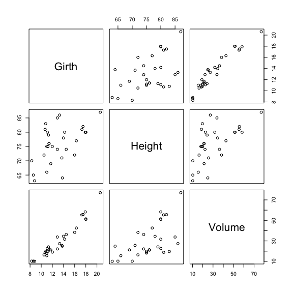

```r
pairs(trees)
```

```r
any(is.na(trees))
```

```
## [1] FALSE
```

## Fitting the model (Solution 1)

```r
trees$HG2 <- trees$Height*trees$Girth^2
mod_trees1 <- lm(Volume ~ HG2 - 1, data = trees)
```

### Checking the assumptions

There is no need to check our first 3 assumptions as the model structure is constrained, but we should check the assumptions concerning the errors.

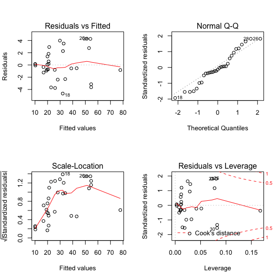

```r
par(mfrow = c(2, 2))
plot(mod_trees1)
```

## Fitting the model (Solution 2)

$\text{Volume} = c \times \text{Height} \times \text{Girth}^2$ is not linear but we can turn it into a linear expression by using logs:

$$\text{log(Volume)} = \text{log}(c) + \text{log(Height)} + 2 \times \text{log(Girth)}$$

We will thus substitute variables by their logs and try to fit the following model:

$$\text{log_Volume} = k + 1 \times \text{log_Height} + 2 \times \text{log_Girth} + \epsilon$$

with $k = \text{log}(c)$. In this LM only $k$ must be estimated and the other slopes are considered as fixed. We thus fit the model as follow:

```r
trees$log_Volume <- log(trees$Volume)
trees$log_Height <- log(trees$Height)
trees$log_Girth <- log(trees$Girth)
mod_trees2 <- lm(log_Volume ~ 1 + offset(log_Height + 2 * log_Girth), data = trees)
```

### Checking the assumptions

```
## hat values (leverages) are all = 0.03225806
##  and there are no factor predictors; no plot no. 5
```

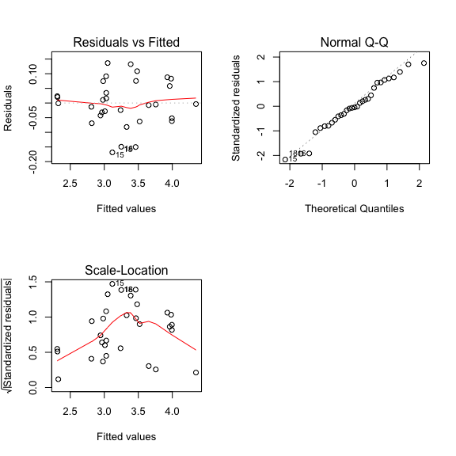

```r
par(mfrow = c(2, 2))
plot(mod_trees2)
```

It looks alright, let’s no forget that we only have `31` rows in the datasets.

## Let us compare how each model fits the data

```r
cor(predict(mod_trees1), trees$Volume)^2
```

```
## [1] 0.9777654
```

```r
cor(exp(predict(mod_trees2)), trees$Volume)^2
```

```
## [1] 0.9777654
```

## Estimation of the parameter $c$

```r
coef(mod_trees1)
```

```
##         HG2
## 0.002108101
```

```r
confint(mod_trees1)
```

```
##           2.5 %      97.5 %
## HG2 0.002052503 0.002163699
```

The estimation with confidence interval of $k$ are:

```r
coef(mod_trees2)
```

```
## (Intercept)
##   -6.169167
```

```r
confint(mod_trees2)
```

```
##                2.5 %    97.5 %
## (Intercept) -6.19818 -6.140155
```

Because $k$ is correspond to the log of $c$, we must raise the obtained value to the exponential to obtain the estimation of $c$:

```r
exp(coef(mod_trees2))
```

```
## (Intercept)
## 0.002092978
```

```r
exp(confint(mod_trees2))
```

```
##                   2.5 %      97.5 %
## (Intercept) 0.002033128 0.002154591
```

We compare the two modelling approach in percentage of the estimation of $c$ by model 1:

```r
100*(coef(mod_trees1)[[1]] - exp(coef(mod_trees2))[[1]])/coef(mod_trees1)[[1]]
```

```
## [1] 0.7173667
```

## Comparison to the approximation of a tree trunk by a cylinder

The volume of a cylinder is the height times the surface of a circle, so $h \pi r^2$ with $r$ the radius or $h\pi(d/2)^2$ with $d$ the diameter. The girth is here the diameter as mentioned in the help file and not the perimeter.

In the formula, all units should be the same but here the diameter is in inches but the height is measured in feet and the volume in cubic feet. This thus lead to the volume of the tree as a cylinder being approximated by $\text{Height} \times \pi \times \left( \text{conv}_\text{in_to_ft} \text{Radius} \right)^2$. Since one foot is 12 inches, $\text{conv}_\text{in_to_ft} = 1/12$, leading to $\text{Volume} = \text{Height} \times \pi \times \left(\frac{\text{Girth}}{24}\right)^2$.

```r
trees$HPG2 <- trees$Height*pi*(trees$Girth/24)^2
mod_trees3 <- lm(Volume ~ -1 + offset(HPG2), data = trees)
```

We can compare both models explicitly:

```r
anova(mod_trees1, mod_trees3)
```

[output not shown]

Let us plot the differences in prediction between models:

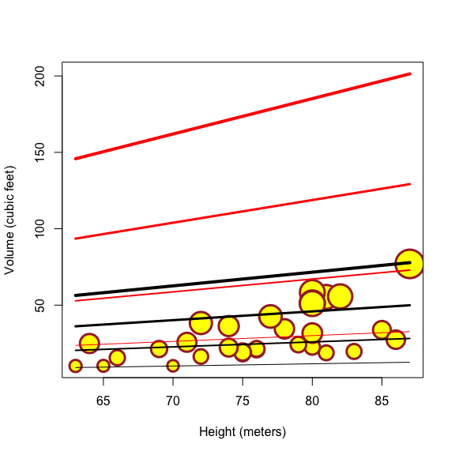

```r
girth.for.pred <- seq(min(trees$Girth), max(trees$Girth), length = 4)
height.for.pred <- seq(min(trees$Height), max(trees$Height), length = 10)
data.for.pred <- expand.grid(Girth = girth.for.pred, Height = height.for.pred)

data.for.pred$HG2 <- data.for.pred$Height*data.for.pred$Girth^2
data.for.pred$HPG2 <- data.for.pred$Height*pi*(data.for.pred$Girth/24)^2

pred1 <- predict(mod_trees1, newdata = data.for.pred)
pred2 <- predict(mod_trees3, newdata = data.for.pred)

data.for.plot <- as.data.frame(cbind(data.for.pred, fit1 = pred1, fit2 = pred2))

plot(Volume ~ Height, data = trees, cex = 5*trees$Girth/max(trees$Girth), pch = 21,
     ylim = range(c(data.for.plot$fit, data.for.plot$fit2, trees$Volume)),
     ylab = "Volume (cubic feet)", xlab = "Height (meters)", col = "brown", bg = "yellow", lwd = 3)

for (girth_class in 1:length(unique(girth.for.pred))) {
  with(subset(data.for.plot,
              data.for.plot$Girth == unique(girth.for.pred)[girth_class]), {
    points(fit1 ~ Height, type = "l", lwd = girth_class)
    points(fit2 ~ Height, type = "l", lwd = girth_class, col = "red")
  })
}
```

That the approximation of the volume of trees as cylinders over-estimate the actual volume may be due to the fact that the diameter of trees goes down as you climb up the tree…

We clean the session for the next exercise:

```r
rm(list = ls())
```

# Dataset: stackloss (difficulty = 1/5)

## Goal

- find out if the acid concentration influences the loss of ammonia by the plants

## Exploring the data

```r
str(stackloss)
```

```
## 'data.frame':    21 obs. of  4 variables:
##  $ Air.Flow  : num  80 80 75 62 62 62 62 62 58 58 ...
##  $ Water.Temp: num  27 27 25 24 22 23 24 24 23 18 ...
##  $ Acid.Conc.: num  89 88 90 87 87 87 93 93 87 80 ...
##  $ stack.loss: num  42 37 37 28 18 18 19 20 15 14 ...
```

```r
summary(stackloss)
```

```
##     Air.Flow       Water.Temp     Acid.Conc.      stack.loss
##  Min.   :50.00   Min.   :17.0   Min.   :72.00   Min.   : 7.00
##  1st Qu.:56.00   1st Qu.:18.0   1st Qu.:82.00   1st Qu.:11.00
##  Median :58.00   Median :20.0   Median :87.00   Median :15.00
##  Mean   :60.43   Mean   :21.1   Mean   :86.29   Mean   :17.52
##  3rd Qu.:62.00   3rd Qu.:24.0   3rd Qu.:89.00   3rd Qu.:19.00
##  Max.   :80.00   Max.   :27.0   Max.   :93.00   Max.   :42.00
```

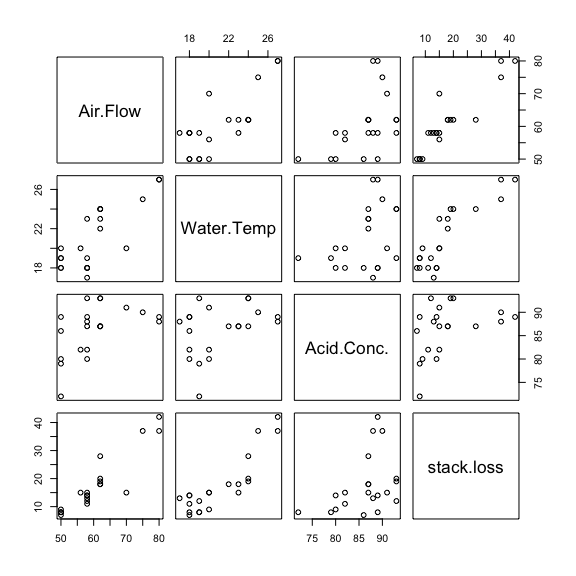

```r
pairs(stackloss)
```

```r
any(is.na(stackloss))
```

```
## [1] FALSE
```

## Fitting the model

```r
mod_stack <- lm(stack.loss ~ ., data = stackloss)
```

## Checking the assumptions

### Linearity

Let’s examine the linearity assumption by plotting the residuals against each column of the design matrix (but the intercept):

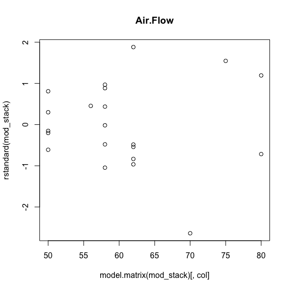

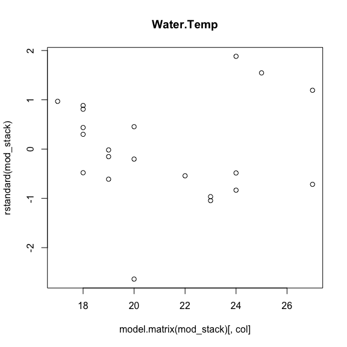

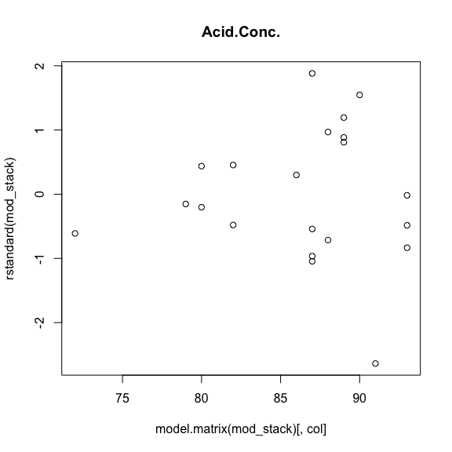

```r
for (col in 2:ncol(model.matrix(mod_stack))) {
  plot(rstandard(mod_stack) ~ model.matrix(mod_stack)[, col])
  title(main = colnames(model.matrix(mod_stack))[col])
}
```

It looks messy but there is no obvious pattern suggesting a particular transformation of the predictors.

### Multicollinearity

```r
cor(model.matrix(mod_stack)[ , -1])
```

```
##             Air.Flow Water.Temp Acid.Conc.
## Air.Flow   1.0000000  0.7818523  0.5001429
## Water.Temp 0.7818523  1.0000000  0.3909395
## Acid.Conc. 0.5001429  0.3909395  1.0000000
```

```r
cov2cor(vcov(mod_stack))
```

```
##             (Intercept)   Air.Flow    Water.Temp    Acid.Conc.
## (Intercept)   1.0000000  0.1792632 -0.1488789541 -0.9015999237
## Air.Flow      0.1792632  1.0000000 -0.7356412819 -0.3389164249
## Water.Temp   -0.1488790 -0.7356413  1.0000000000  0.0001821423
## Acid.Conc.   -0.9015999 -0.3389164  0.0001821423  1.0000000000
```

```r
vif(mod_stack)
```

```
##   Air.Flow Water.Temp Acid.Conc.
##   2.906484   2.572632   1.333587
```

There are some multicollinearity problems but it does not seem to impact much the effect of acidity which is our focus.

### Other assumptions

We will assume that no there is no measurement error and will focus on the analysis of the prediction error of the model:

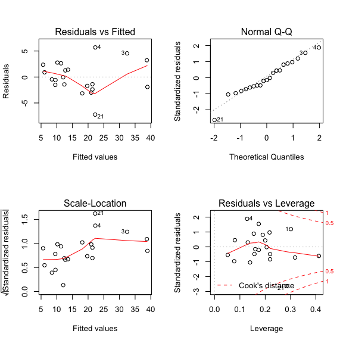

```r
par(mfrow = c(2, 2))
plot(mod_stack)
```

That is not fantastic but it is not specifically worse than what we may get under the assumption of LM with so few data. We can check this by simulating data under the assumption of LM and comparing the plots we get:

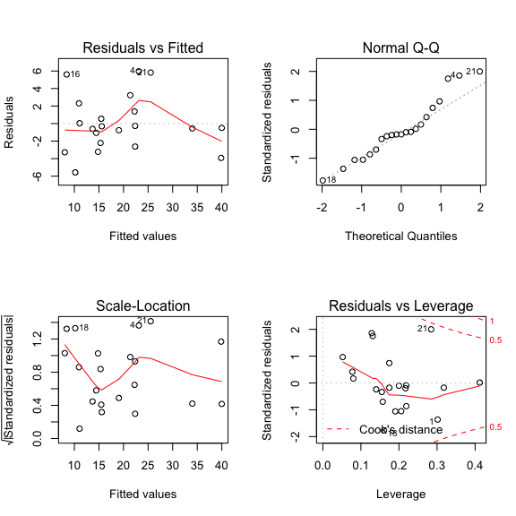

```r
par(mfrow = c(2, 2))
plot(update(mod_stack, as.matrix(simulate(mod_stack)) ~ .))  ## simulation 1
```

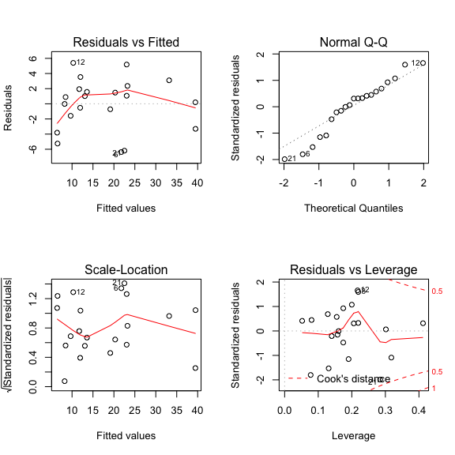

```r
plot(update(mod_stack, as.matrix(simulate(mod_stack)) ~ .))  ## simulation 2
```

It does not look particularly better, so we will consider the assumptions fulfilled.

## Comparison to the null model

Because the model involves several predictors, before anything else we need to make sure that the overall model offers a higher goodness of fit than the null model:

```r
mod_stack_H0 <- update(mod_stack, . ~ 1)
anova(mod_stack_H0, mod_stack)
```

```
## Analysis of Variance Table
##
## Model 1: stack.loss ~ 1
## Model 2: stack.loss ~ Air.Flow + Water.Temp + Acid.Conc.
##   Res.Df     RSS Df Sum of Sq      F    Pr(>F)
## 1     20 2069.24
## 2     17  178.83  3    1890.4 59.902 3.016e-09 ***
## ---
## Signif. codes:  0 '***' 0.001 '**' 0.01 '*' 0.05 '.' 0.1 ' ' 1
```

All good, the model predicts the data significantly better than the null model.

## Testing the effect of the acid concentration

```r
summary(mod_stack)$coef["Acid.Conc.", ]
```

```
##   Estimate Std. Error    t value   Pr(>|t|)
## -0.1521225  0.1562940 -0.9733098  0.3440461
```

The acid seems to have no significant influence on the loss of ammonia (t = `-0.97`, df = `17`, p-value = `0.34`).

Let’s plot the effect using `effects`.

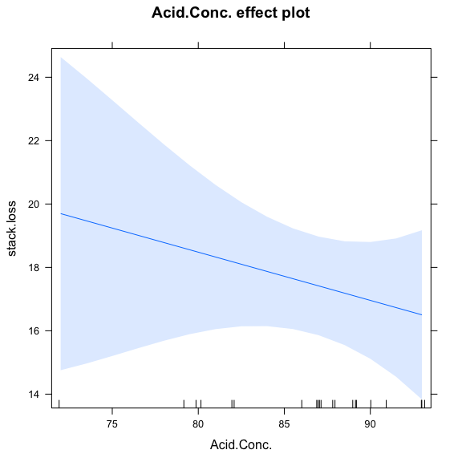

```r
plot(effects::effect("Acid.Conc.", mod = mod_stack))
```

## Considering interactions?

Because we are specifically interested in the effect of the acid and that this effect may depend on the other predictors, we could check if considering interaction between the acidity and other predictors would improve the goodness of fit of the model:

```r
mod_stack_int <- lm(stack.loss ~ Acid.Conc. * (Air.Flow + Water.Temp), data = stackloss)
anova(mod_stack, mod_stack_int)
```

```
## Analysis of Variance Table
##
## Model 1: stack.loss ~ Air.Flow + Water.Temp + Acid.Conc.
## Model 2: stack.loss ~ Acid.Conc. * (Air.Flow + Water.Temp)
##   Res.Df    RSS Df Sum of Sq      F Pr(>F)
## 1     17 178.83
## 2     15 168.38  2    10.446 0.4653 0.6367
```

```r
vif(mod_stack_int)
```

```
##            Acid.Conc.              Air.Flow            Water.Temp
##              224.6593             1156.7148             1422.5941
##   Acid.Conc.:Air.Flow Acid.Conc.:Water.Temp
##             1742.5261             2050.1087
```

The goodness of fit is not significantly better and there are huge multicollinearity issues, so let’s not go there.

That is all for now!